# Empirical Power Analysis

Matt Jaquiery

09/03/2020

## Introduction

| Decision | $H_0$ = TRUE | $H_1$ = TRUE |
| --- | --- | --- |
| Reject $H_0$ | Type 1 error ($p = \alpha$) | Correct rejection ($p = 1 - \beta$) |
| Accept $H_0$ | Correct ($p = 1 - \alpha$) | Type 2 error ($p = \beta$) |

($\alpha$ = long-term false-positive rate; $\beta$ = long-term false-negative rate)

The contingency table above demonstrates how the empirical power analysis presented below will work. We will be simulating data, so we will be controlling whether or not $H_0$ is true. This means that we’ll be looking at one column at a time, and will thus be able to determine the empirical $\alpha$ and $\beta$ values from the proportion of $H_0$ rejections.

## Simulation

We are going to set up a general purpose power curve/heatmap workflow which will take any function and call it repeatedly with the arguments of sample size and effect size. To keep things simple we’ll write a wrapper for simulating t-test data, but this can be arbitrarily complex.

The wrapper function generates two sets of $n$ observations from normal distributions with standard deviations = 1 and means = to 0 and $\text{effect_size}$. It then performs an independent samples t-test on these sets and reports the p-value.

When we call this function we get the parameters we gave it (sample size, effect size, and a combination id) as well as a p-value of the t-test run on the simulated data:

```
# A tibble: 1 x 4
      n effect_size combination       p
  <dbl>       <dbl> <lgl>         <dbl>
1    30         0.9 NA          0.00199
```

## Power curve

Now we can simulate data, we can construct a power curve by inspecting p-values for several different sample sizes:

```
    n effect_size combination      p
1   5         0.9           1   .367
2   6         0.9           2   .030
3   7         0.9           3   .209
4   8         0.9           4   .003
5   9         0.9           5   .013
6  10         0.9           6   .409
7  11         0.9           7   .221
8  12         0.9           8   .004
9  13         0.9           9   .008
10 14         0.9          10   .030
11 15         0.9          11   .009
12 16         0.9          12   .128
13 17         0.9          13   .167
14 18         0.9          14   .005
15 19         0.9          15   .013
16 20         0.9          16 < .001
17 21         0.9          17   .161
18 22         0.9          18 < .001
19 23         0.9          19 < .001
20 24         0.9          20 < .001
21 25         0.9          21 < .001
```

We can plot these p-values against the sample size which generated them.

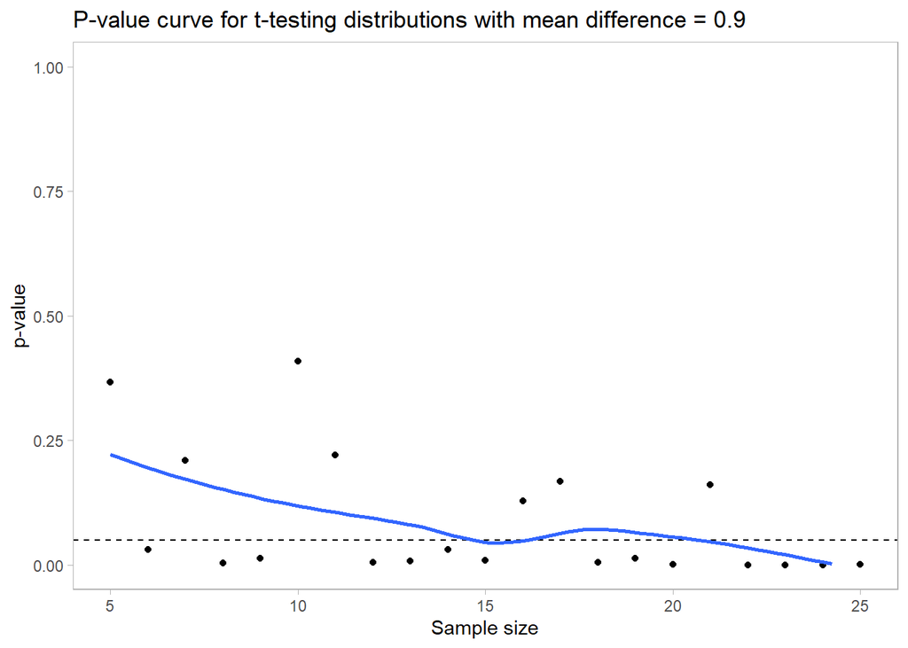

As we can see, there’s a bit of a scattering of p-values. We can get a better picture of what’s going on by running multiple copies (100) of each simulation.

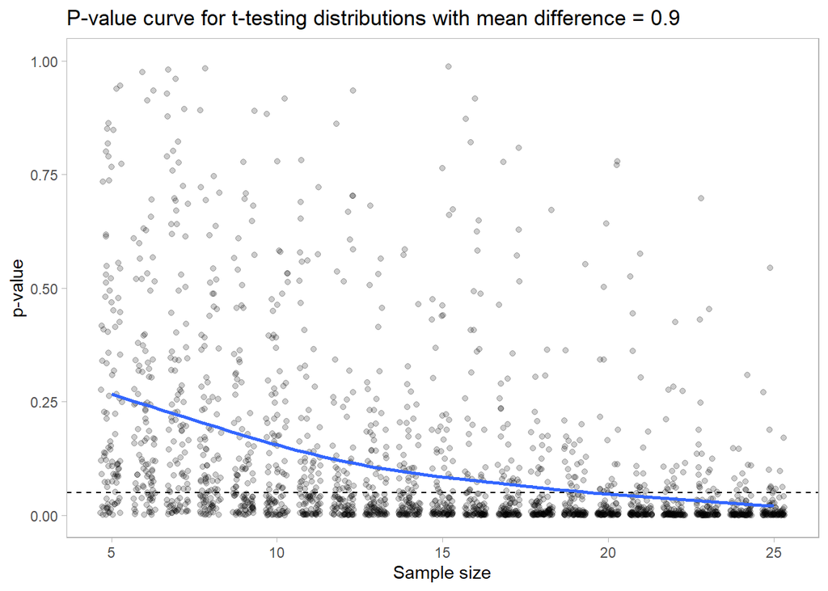

We’re now starting to see the power curve emerge over the 100 runs at each sample size. We can see what this would look like with a smaller effect size, too.

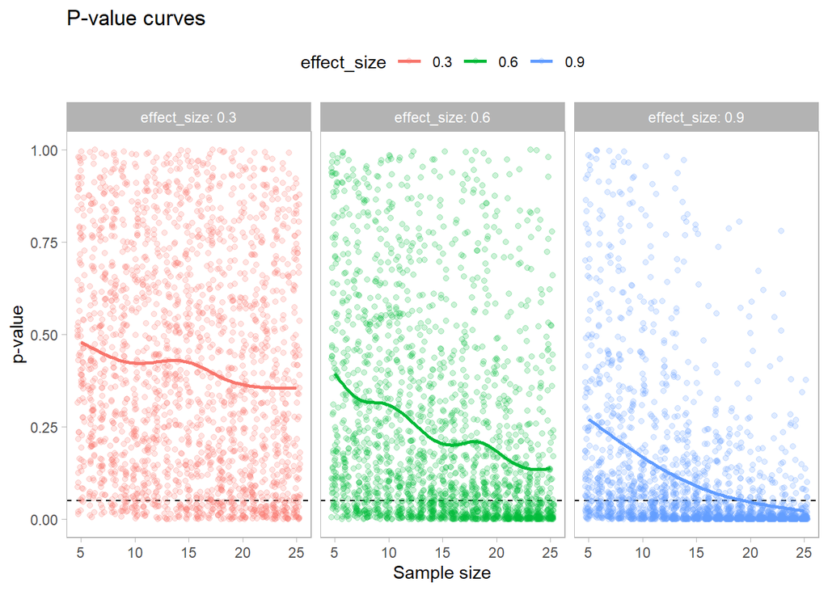

## Heatmap

We can collapse these observations into the manifold represented by the line - a vector of values expressing the relationship between the mean p-value and the sample size. Better still, we can take the closely related manifold expressing the proportion of the t-tests which had p-values < .05.

With our 2d space collapsed to a 1d space, we can add in an extra dimension which we can use to vary the effect size. Our current data represented in this format looks like this:

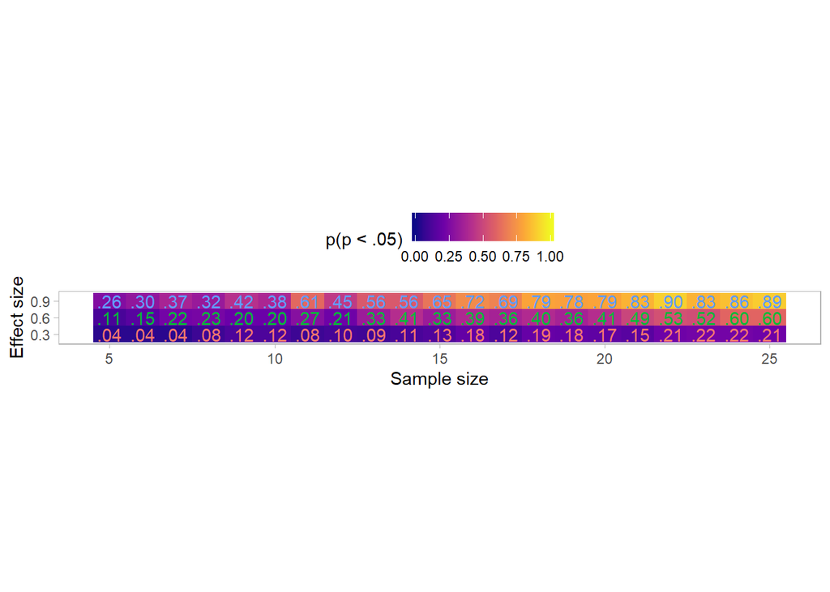

We are now in a position to simulate this with many iterations (1000 per cell) and many different levels of effect size. We will also add *s where the power is > .85 so we can identify sample sizes we might want to adopt at each effect size.

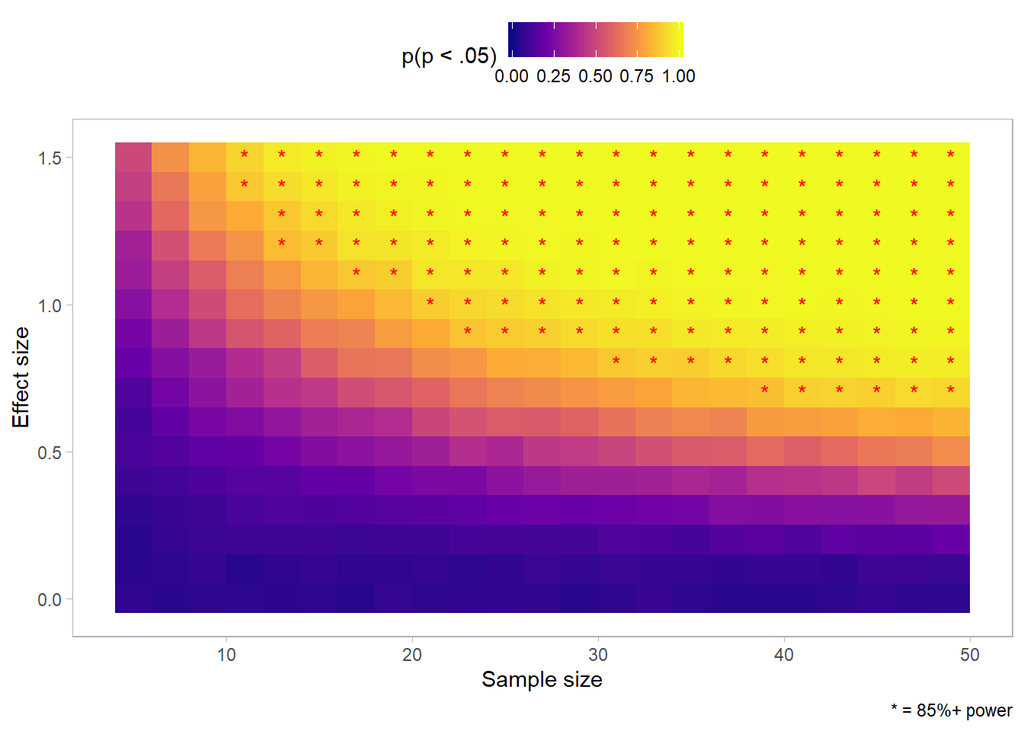